# Homework 2

2023-05-30

# 1 Data Visualisation - Exploration

Now that you’ve demonstrated your software is setup, and you have the basics of data manipulation, the goal of this assignment is to practice transforming, visualising, and exploring data.

# 2 Exploring sources of electricity production, CO2 emissions, and GDP per capita.

There are many sources of data on how countries generate their electricity and their CO2 emissions. I would like you to create three graphs:

## 2.1 1. A stacked area chart that shows how your own country generated its electricity since 2000.

You will use

`geom_area(colour="grey90", alpha = 0.5, position = "fill")`

## 2.2 2. A scatter plot that looks at how CO2 per capita and GDP per capita are related

## 2.3 3. A scatter plot that looks at how electricity usage (kWh) per capita/day GDP per capita are related

We will get energy data from the Our World in Data website, and CO2 and GDP per capita emissions from the World Bank, using the `wbstats`package.

```r
# Download electricity data
url <- "https://nyc3.digitaloceanspaces.com/owid-public/data/energy/owid-energy-data.csv"

energy <- read_csv(url) %>%
  filter(year >= 1990) %>%
  drop_na(iso_code) %>%
  select(1:3,
         biofuel = biofuel_electricity,
         coal = coal_electricity,
         gas = gas_electricity,
         hydro = hydro_electricity,
         nuclear = nuclear_electricity,
         oil = oil_electricity,
         other_renewable = other_renewable_exc_biofuel_electricity,
         solar = solar_electricity,
         wind = wind_electricity,
         electricity_demand,
         electricity_generation,
         net_elec_imports,  # Net electricity imports, measured in terawatt-hours
         energy_per_capita, # Primary energy consumption per capita, measured in kilowatt-hours Calculated by Our World in Data based on BP Statistical Review of World Energy and EIA International Energy Data
         energy_per_gdp,    # Energy consumption per unit of GDP. This is measured in kilowatt-hours per 2011 international-$.
         per_capita_electricity, #  Electricity generation per capita, measured in kilowatt-hours
  )

# Download data for C02 emissions per capita https://data.worldbank.org/indicator/EN.ATM.CO2E.PC
co2_percap <- wb_data(country = "countries_only",
                      indicator = "EN.ATM.CO2E.PC",
                      start_date = 1990,
                      end_date = 2022,
                      return_wide=FALSE) %>%
  filter(!is.na(value)) %>%
  #drop unwanted variables
  select(-c(unit, obs_status, footnote, last_updated)) %>%
  rename(year = date,
         co2percap = value)


# Download data for GDP per capita  https://data.worldbank.org/indicator/NY.GDP.PCAP.PP.KD
gdp_percap <- wb_data(country = "countries_only",
                      indicator = "NY.GDP.PCAP.PP.KD",
                      start_date = 1990,
                      end_date = 2022,
                      return_wide=FALSE) %>%
  filter(!is.na(value)) %>%
  #drop unwanted variables
  select(-c(unit, obs_status, footnote, last_updated)) %>%
  rename(year = date,
         GDPpercap = value)
```

Specific questions:

1. How would you turn `energy` to long, tidy format?

```r
energy %>%
  filter(country == "Mexico")
```

```
## # A tibble: 32 × 18
##    country  year iso_code biofuel  coal   gas hydro nuclear   oil
##    <chr>   <dbl> <chr>      <dbl> <dbl> <dbl> <dbl>   <dbl> <dbl>
##  1 Mexico   1990 MEX           NA  7.80  13.2  24.5    2.94  64.0
##  2 Mexico   1991 MEX           NA  9.24  18.9  22.6    4.24  67.7
##  3 Mexico   1992 MEX           NA  9.55  18.8  26.8    3.92  66.8
##  4 Mexico   1993 MEX           NA 11.6   19.1  26.7    4.93  65.9
##  5 Mexico   1994 MEX           NA 14.3   21.4  20.3    4.24  79.7
##  6 Mexico   1995 MEX           NA 15.5   22.4  27.6    8.44  70.0
##  7 Mexico   1996 MEX           NA 18.5   21.2  31.3    7.88  71.5
##  8 Mexico   1997 MEX           NA 18.4   23.1  26.4   10.5   82.5
##  9 Mexico   1998 MEX           NA 18.7   30.0  24.6    9.26  92.3
## 10 Mexico   1999 MEX           NA 18.6   32.9  32.7   10.0   89.7
## # ℹ 22 more rows
## # ℹ 9 more variables: other_renewable <dbl>, solar <dbl>, wind <dbl>,
## #   electricity_demand <dbl>, electricity_generation <dbl>,
## #   net_elec_imports <dbl>, energy_per_capita <dbl>, energy_per_gdp <dbl>,
## #   per_capita_electricity <dbl>
```

```r
energy_long <- energy %>%
  select(1:12) %>%
  pivot_longer(cols = 4:12,
               names_to = 'source',
               values_to = 'value') %>%
  drop_na(value) %>%
  drop_na(iso_code)



energy_long %>%
  filter(country == "Mexico")
```

```
## # A tibble: 268 × 5
##    country  year iso_code source   value
##    <chr>   <dbl> <chr>    <chr>    <dbl>
##  1 Mexico   1990 MEX      coal     7.80
##  2 Mexico   1990 MEX      gas     13.2
##  3 Mexico   1990 MEX      hydro   24.5
##  4 Mexico   1990 MEX      nuclear  2.94
##  5 Mexico   1990 MEX      oil     64.0
##  6 Mexico   1990 MEX      solar    0.001
##  7 Mexico   1990 MEX      wind     0.001
##  8 Mexico   1991 MEX      coal     9.24
##  9 Mexico   1991 MEX      gas     18.9
## 10 Mexico   1991 MEX      hydro   22.6
## # ℹ 258 more rows
```

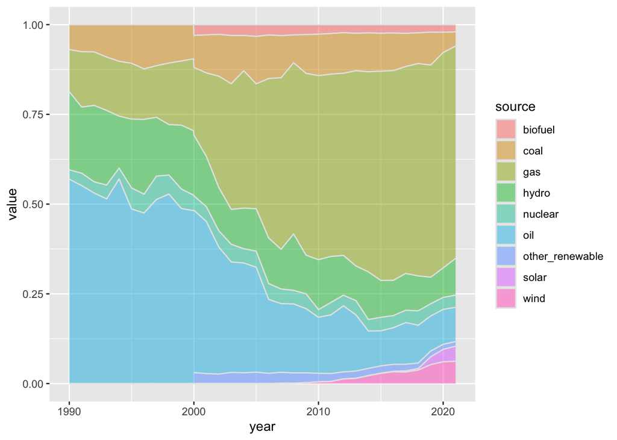

```r
energy_long %>%
  filter(country == "Mexico") %>%
  ggplot()+
  aes(x= year, y = value, fill = source)+
  geom_area(colour="grey90", alpha = 0.5, position = "fill")
```

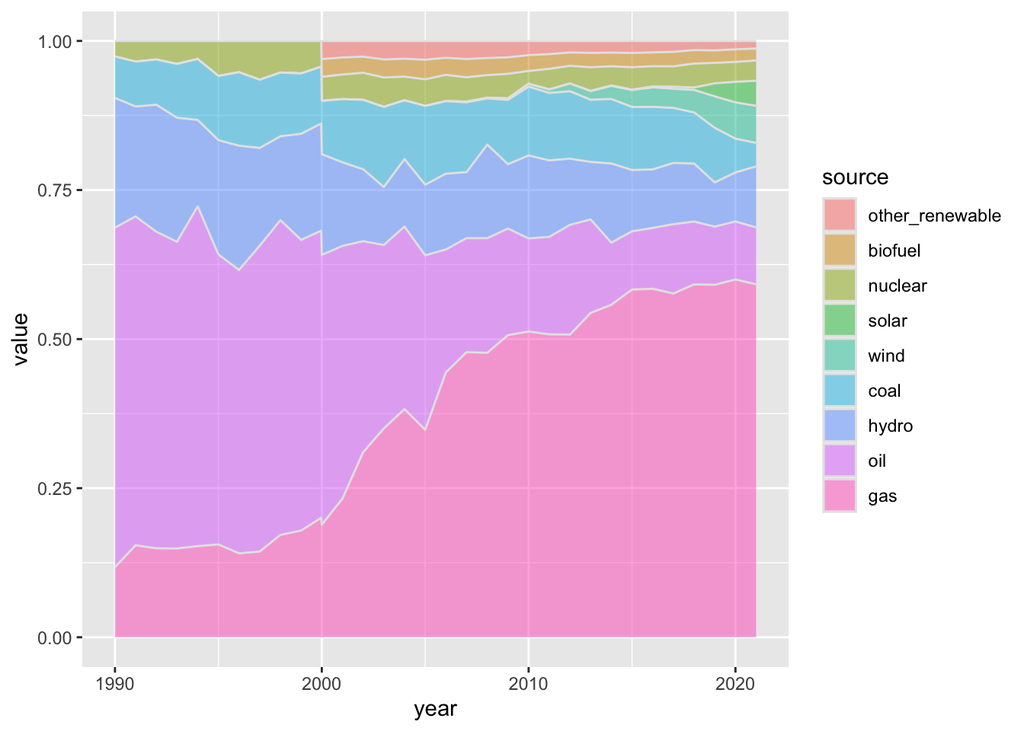

```r
energy_long %>%
  filter(country == "Mexico") %>%
  mutate(source = fct_reorder(source, value, max)) %>%
  ggplot()+
  aes(x= year, y = value, fill = source)+
  geom_area(colour="grey90", alpha = 0.5, position = "fill")
```

2. You may need to join these data frames
   - Use `left_join` from `dplyr` to [join the tables](http://r4ds.had.co.nz/relational-data.html)
   - To complete the merge, you need a unique *key* to match observations between the data frames. Country names may not be consistent among the three dataframes, so please use the 3-digit ISO code for each country

```r
country_names <- energy_long %>%
  distinct(iso_code, country) %>%
  select(iso_code, country)

join1 <- gdp_percap %>%
  left_join(co2_percap, by = c("country", "year")) %>%
  select(iso_code = iso3c.x, country, year, GDPpercap, co2percap) %>%
  left_join(country_names, by = "iso_code") %>%
  rename(country = country.y)


join2 <- join1 %>%
  left_join(energy, by = c("country", "year"))
```

[output not shown]

3. Write a function that takes as input any country’s name and returns all three graphs. You can use the `patchwork` package to arrange the three graphs

```r
library(viridis)
```

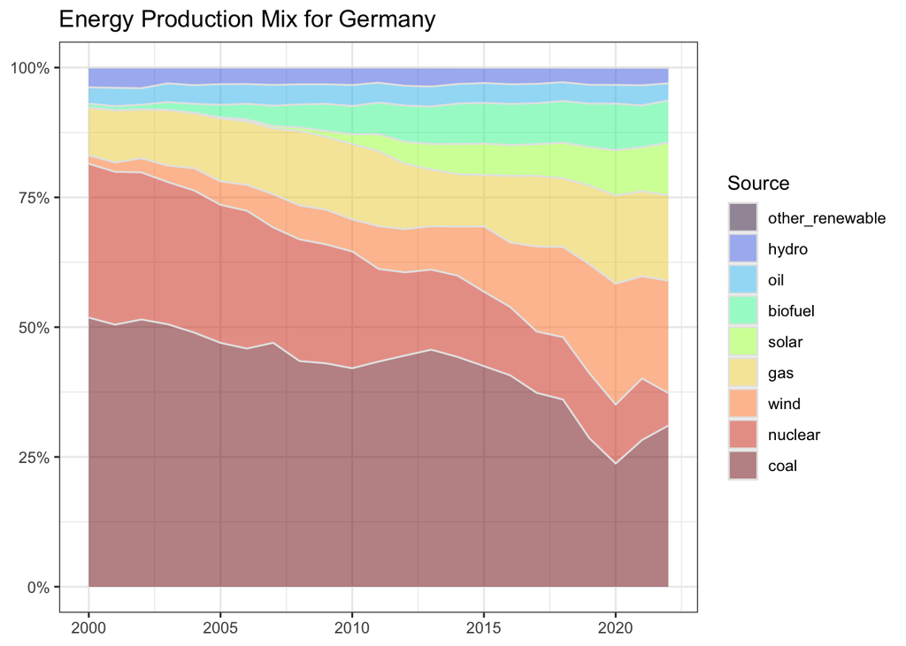

```r
energy_mix <- function(country) {

  energy %>%
    select(1:2, 4:12) %>% # we will now have 11 columns
    pivot_longer(cols = 3:11,
                 names_to = "source",
                 values_to = "value") %>%

    filter(country == {{country}}, year >= 2000) %>%

    mutate(source = fct_reorder(source, value, max)) %>%
    drop_na(value) %>%


    ggplot()+
    aes(x=year, y = value, fill=source )+
    geom_area(color="grey90",
              alpha = 0.5,
              position = "fill")+ # so you get to 100%
    theme_bw()+
    scale_fill_viridis(discrete = T,
                       option = "H") +
    scale_y_continuous(labels = scales::percent)+
    labs(title = glue::glue("Energy Production Mix for ", {{country}}),
         x=NULL,
         y=NULL,
         fill= "Source")
}

energy_mix("Germany")
```

A function that plots top n countries for a chosen fuel in a certain year

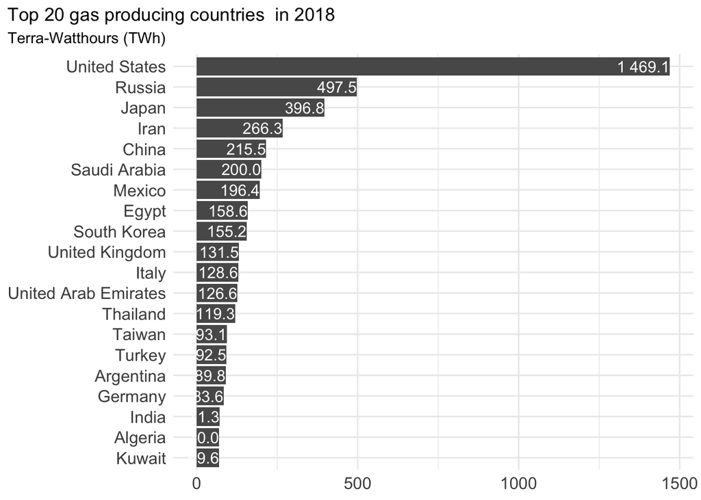

```r
energy_long <-   energy %>%
    select(1:2, 4:12) %>% # we will now have 11 columns
    pivot_longer(cols = 3:11,
                 names_to = "source",
                 values_to = "value")


top_fuel <- function(.source, .year, .n) {

  energy_long %>%

    filter(year == .year,
           source == .source) %>%
    drop_na(value) %>%
    mutate(country  =  fct_reorder(country, value)) %>%
    slice_max(order_by = value, n = .n) %>%
    ggplot(aes(x = value, y = country)) +
    geom_col() +
    theme_minimal()+
    geom_text(
      aes(label = scales::number(value, accuracy = 0.1), x = value - .25),
      colour = "white",
      size = 4,
      hjust = 1
    ) +
    labs(
      title = paste0("Top ",.n," ", .source, " producing countries ", " in ",.year),
      subtitle = "Terra-Watthours (TWh)",
      x= NULL,
      y = NULL
    )+
    theme(
      plot.title.position = "plot",
  #    plot.title = element_textbox_simple(size=16),
      axis.title.y = element_text(angle = 0, vjust = 0.5,size=14),
      axis.text = element_text(size=12),
      legend.position = "none") +
    NULL
}

top_fuel("gas", 2018, 20)
```

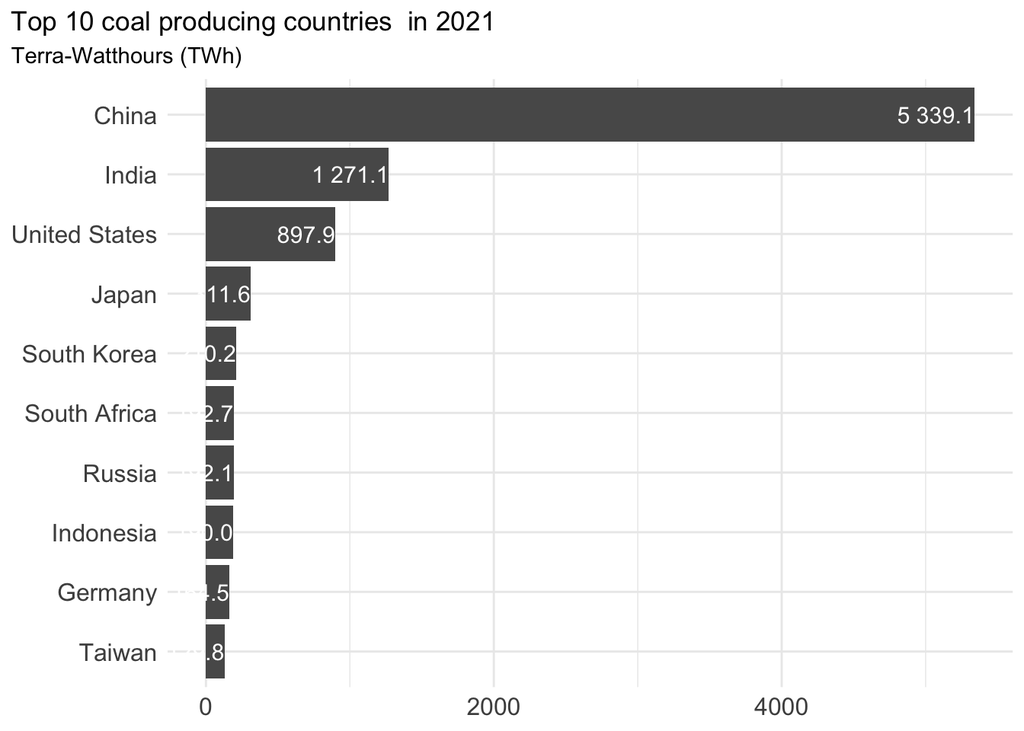

```r
top_fuel("coal", 2021, 10)
```

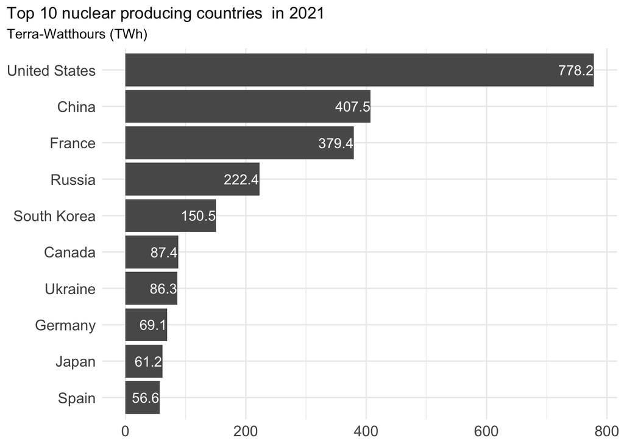

```r
top_fuel("nuclear", 2021, 10)
```

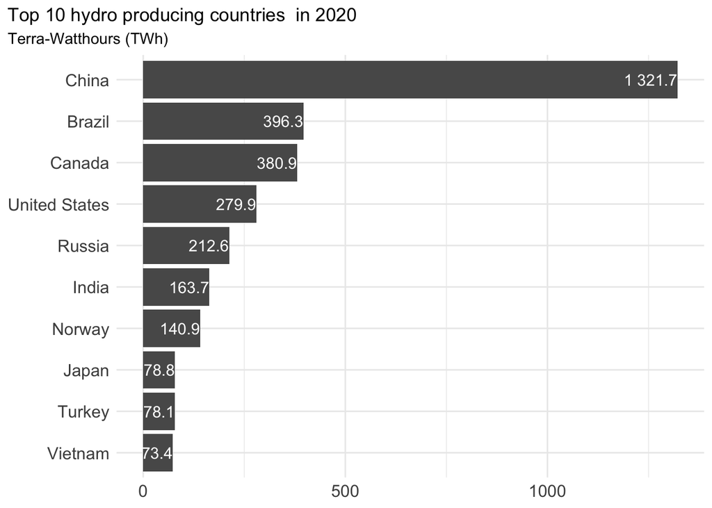

```r
top_fuel("hydro", 2020, 10)
```

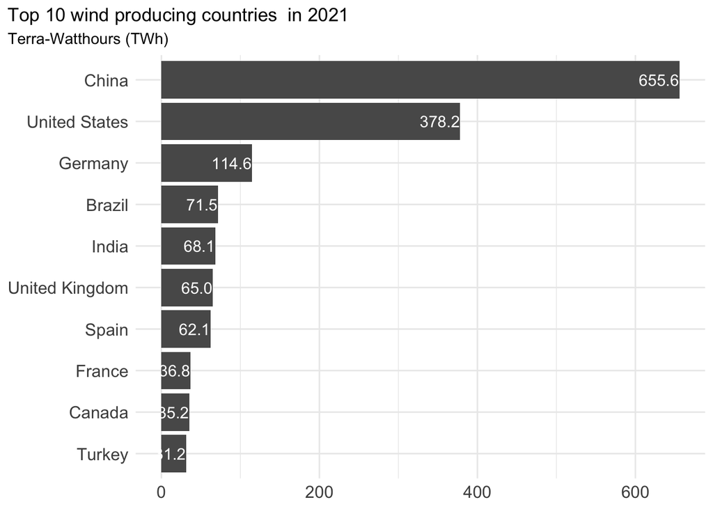

```r
top_fuel("wind", 2021, 10)
```

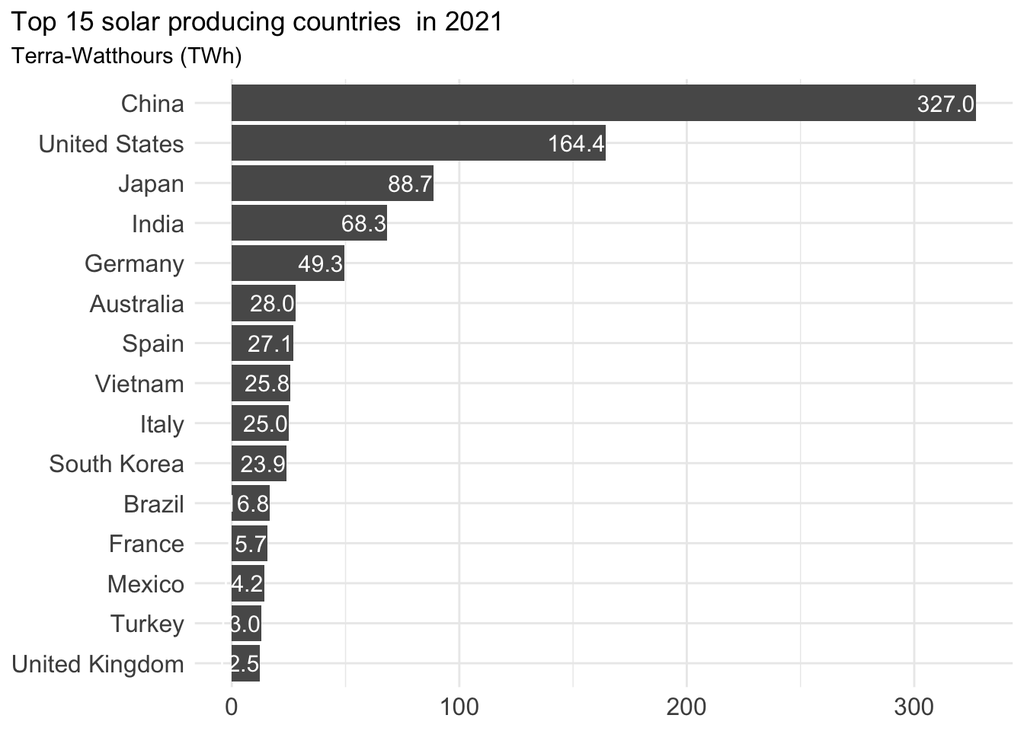

```r
top_fuel("solar", 2021, 15)
```

A function that takes a country as inoput and returns 3 graphs

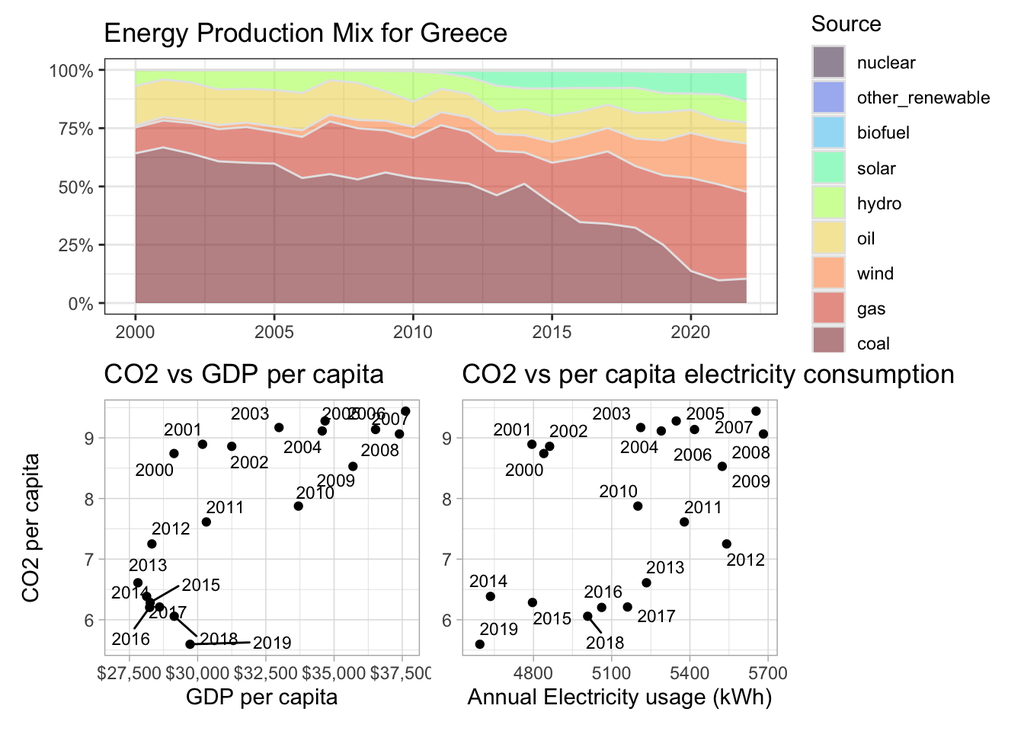

```r
library(viridis)
library(patchwork)
library(ggrepel)

energy_mix_co2_gdp <- function(country) {

  plot1 <- energy %>%
    select(1:2, 4:12) %>% # we will now have 11 columns
    pivot_longer(cols = 3:11,
                 names_to = "source",
                 values_to = "value") %>%

    filter(country == {{country}}, year >= 2000) %>%
    drop_na(value) %>%
    mutate(source = fct_reorder(source, value, max)) %>%



    ggplot()+
    aes(x=year, y = value, fill=source )+
    geom_area(color="grey90",
              alpha = 0.5,
              position = "fill")+ # so you get to 100%
    theme_bw()+
    scale_fill_viridis(discrete = T,
                       option = "H") +
    scale_y_continuous(labels = scales::percent)+
    labs(title = glue::glue("Energy Production Mix for ", {{country}}),
         x=NULL,
         y=NULL,
         fill= "Source")

  plot2 <- join2 %>%
    select(year, country, GDPpercap, co2percap, per_capita_electricity) %>%
    filter(country == {{country}}, year >= 2000) %>%

    ggplot()+
    aes(x=GDPpercap, y=co2percap, label=year)+
    geom_point()+
    geom_text_repel(size=3)+
    theme_light() +
    scale_x_continuous(labels = scales::dollar)+
    labs(title = "CO2 vs GDP per capita",
         x = "GDP per capita",
         y = "CO2 per capita")

  plot3 <- join2 %>%
    select(year, country, GDPpercap, co2percap, per_capita_electricity) %>%
    filter(country == {{country}}, year >= 2000) %>%

    ggplot()+
    aes(x=per_capita_electricity, y=co2percap, label=year)+
    geom_point()+
    geom_text_repel(size=3)+
    theme_light()+
    labs(title = "CO2 vs per capita electricity consumption",
         x = "Annual Electricity usage (kWh)",
         y = NULL)


# use patchwork to arrange plots
plot1 / (plot2 + plot3)
}

energy_mix_co2_gdp("Greece")
```

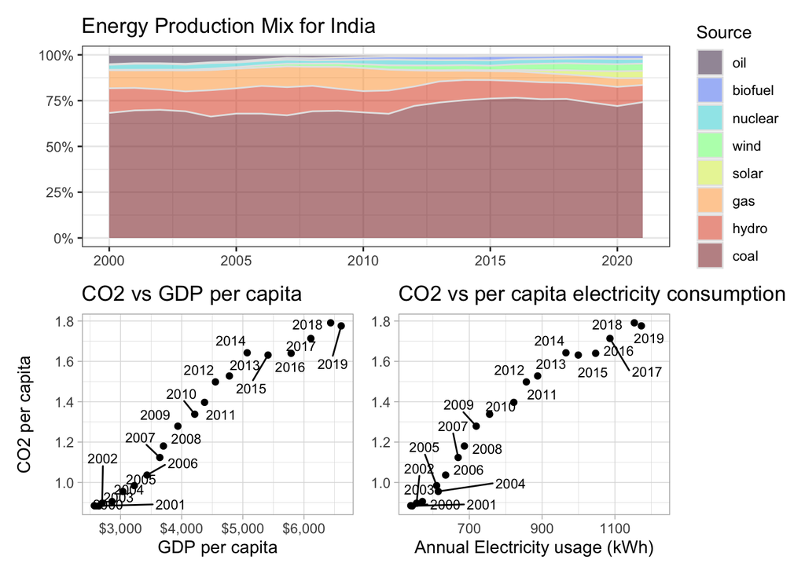

```r
energy_mix_co2_gdp("India")
```

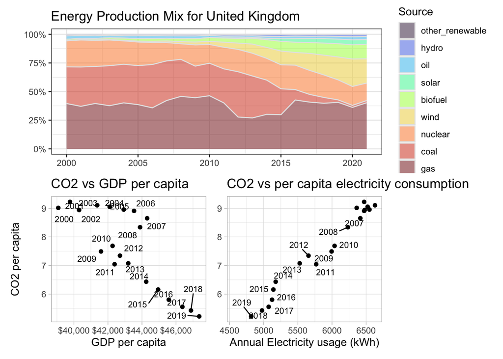

```r
energy_mix_co2_gdp("United Kingdom")
```

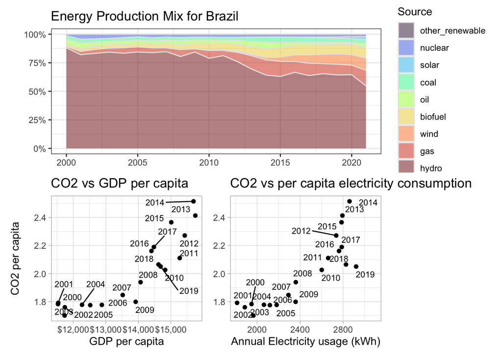

```r
energy_mix_co2_gdp("Brazil")
```

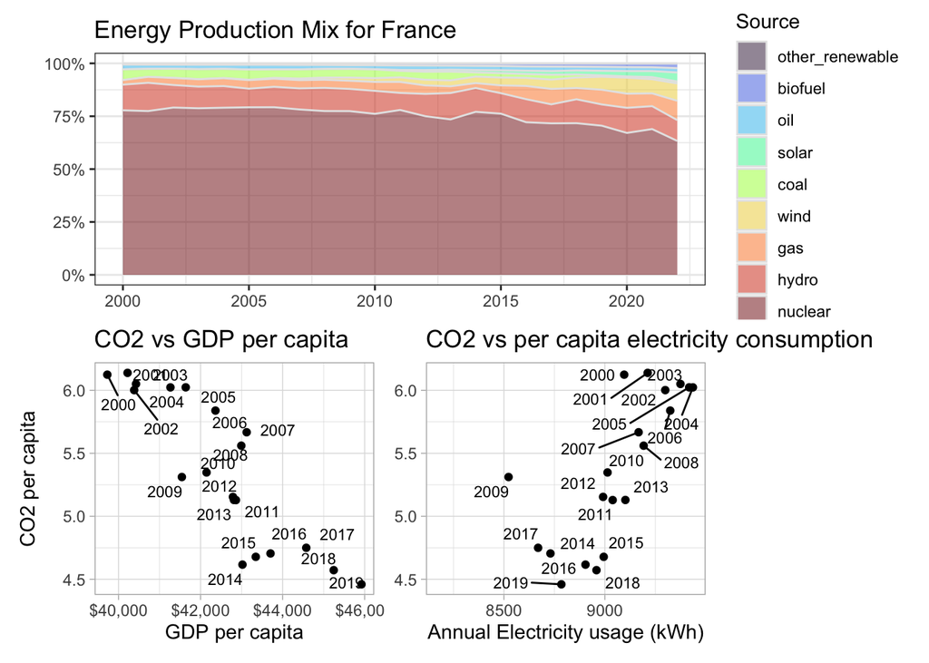

```r
energy_mix_co2_gdp("France")
```

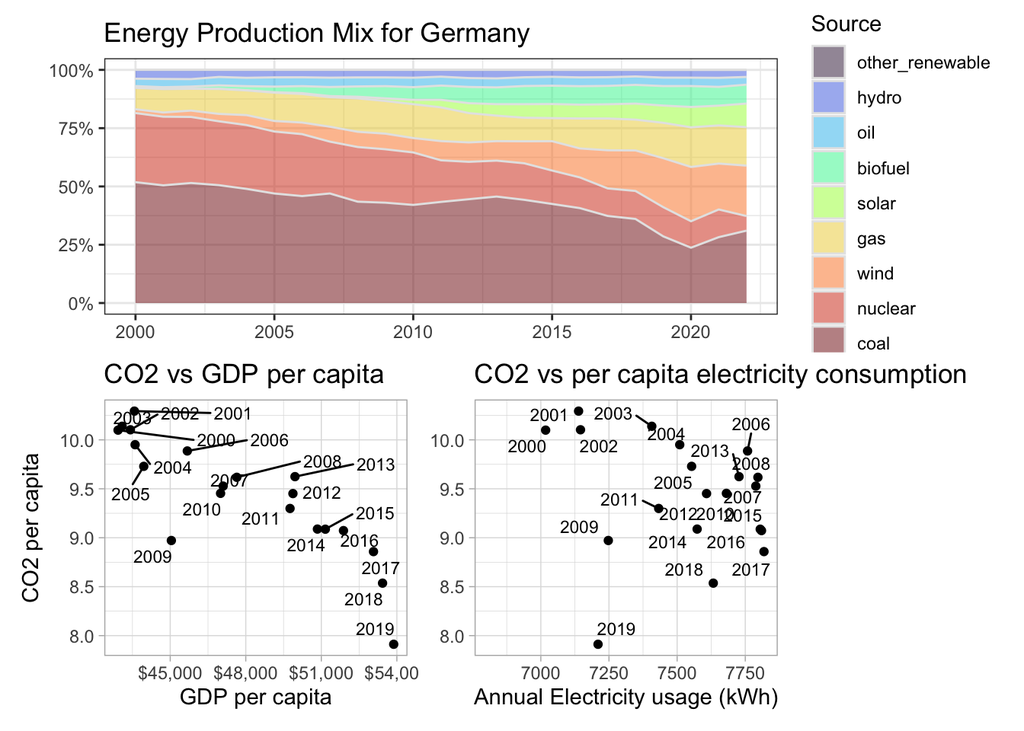

```r
energy_mix_co2_gdp("Germany")
```